# Sentencing Exploratory Data Analysis

Laurie Baker, Lily Khadjavi, and José Pabón

2023-07-19

```r
library(tidyverse)
library(readr)
```

## Reading in the data

First you will want to read in your data. You can do this using `read_csv`. To open the data you can “uncomment” (delete the hash tag #) to view the data file. Note that you will need to “recomment” this out in order to knit your file again.

## Describe the structure of the data

In a tidy dataset, each row is an observation, each column is a variable, and each cell is a value.

In this case each row represents an individual who was sentenced in the federal district court system in the U.S. in one of the 94 districts in the U.S.

When we start with a dataset we will want to think about and explore some key questions related to who is in our dataset, what the sentence was, when the individual was sentenced and where the sentence occurred.

Let’s inspect our variables which are in the columns.

```r
names(us_sent)
```

```
##  [1] "sentence_length"             "age"
##  [3] "sex"                         "educ"
##  [5] "year"                        "guilty_plea"
##  [7] "base_chapter2_adjustments"   "base_chapter2_3_adjustments"
##  [9] "all_adjustments"             "grid_cell"
## [11] "mandatory_min"               "gov_departures"
## [13] "district"                    "race"
## [15] "criminal_history"
```

```r
summary(us_sent)
```

```
##  sentence_length       age             sex              educ
##  Min.   :  0.00   Min.   :16.00   Min.   :0.0000   Min.   :1.000
##  1st Qu.: 12.03   1st Qu.:28.00   1st Qu.:0.0000   1st Qu.:1.000
##  Median : 41.00   Median :35.00   Median :0.0000   Median :3.000
##  Mean   : 62.96   Mean   :36.96   Mean   :0.1681   Mean   :3.101
##  3rd Qu.: 87.00   3rd Qu.:44.00   3rd Qu.:0.0000   3rd Qu.:5.000
##  Max.   :470.00   Max.   :97.00   Max.   :1.0000   Max.   :6.000
##       year       guilty_plea     base_chapter2_adjustments
##  Min.   :2006   Min.   :0.0000   Min.   :-8.00
##  1st Qu.:2009   1st Qu.:0.0000   1st Qu.:16.00
##  Median :2013   Median :0.0000   Median :24.00
##  Mean   :2013   Mean   :0.0454   Mean   :23.21
##  3rd Qu.:2017   3rd Qu.:0.0000   3rd Qu.:30.00
##  Max.   :2020   Max.   :1.0000   Max.   :53.00
##  base_chapter2_3_adjustments all_adjustments  grid_cell         mandatory_min
##  Min.   : 1.00               Min.   : 1.00   Length:518719      Mode :logical
##  1st Qu.:16.00               1st Qu.:14.00   Class :character   FALSE:453517
##  Median :24.00               Median :21.00   Mode  :character   TRUE :65202
##  Mean   :23.52               Mean   :21.31
##  3rd Qu.:30.00               3rd Qu.:28.00
##  Max.   :64.00               Max.   :43.00
##  gov_departures    district             race           criminal_history
##  Mode :logical   Length:518719      Length:518719      Min.   :1.000
##  FALSE:417903    Class :character   Class :character   1st Qu.:1.000
##  TRUE :100816    Mode  :character   Mode  :character   Median :2.000
##                                                        Mean   :2.655
##                                                        3rd Qu.:4.000
##                                                        Max.   :6.000
```

```r
str(us_sent)
```

```
## spc_tbl_ [518,719 × 15] (S3: spec_tbl_df/tbl_df/tbl/data.frame)
##  $ sentence_length            : num [1:518719] 0.46 90 65 87 60 62 84 120 53 0 ...
##  $ age                        : num [1:518719] 36 21 35 26 30 23 29 26 45 36 ...
##  $ sex                        : num [1:518719] 0 0 0 0 0 0 0 0 0 1 ...
##  $ educ                       : num [1:518719] 3 3 1 1 3 5 1 3 3 3 ...
##  $ year                       : num [1:518719] 2006 2006 2006 2006 2006 ...
##  $ guilty_plea                : num [1:518719] 0 0 0 0 0 0 0 0 0 0 ...
##  $ base_chapter2_adjustments  : num [1:518719] 38 18 28 32 28 28 28 14 20 20 ...
##  $ base_chapter2_3_adjustments: num [1:518719] 38 18 28 32 28 28 26 14 20 20 ...
##  $ all_adjustments            : num [1:518719] 35 15 25 29 26 25 23 34 17 17 ...
##  $ grid_cell                  : chr [1:518719] "XFOLSOR35XCRHISSR5" "XFOLSOR15XCRHISSR4" "XFOLSOR25XCRHISSR2" "XFOLSOR29XCRHISSR3" ...
##  $ mandatory_min              : logi [1:518719] FALSE TRUE FALSE FALSE FALSE TRUE ...
##  $ gov_departures             : logi [1:518719] TRUE FALSE FALSE FALSE FALSE FALSE ...
##  $ district                   : chr [1:518719] "Dist of Columbia" "Dist of Columbia" "Dist of Columbia" "Dist of Columbia" ...
##  $ race                       : chr [1:518719] "white" "black" "black" "black" ...
##  $ criminal_history           : num [1:518719] 5 4 2 3 5 1 5 6 4 1 ...
##  - attr(*, "spec")=
##   .. cols(
##   ..   sentence_length = col_double(),
##   ..   age = col_double(),
##   ..   sex = col_double(),
##   ..   educ = col_double(),
##   ..   year = col_double(),
##   ..   guilty_plea = col_double(),
##   ..   base_chapter2_adjustments = col_double(),
##   ..   base_chapter2_3_adjustments = col_double(),
##   ..   all_adjustments = col_double(),
##   ..   grid_cell = col_character(),
##   ..   mandatory_min = col_logical(),
##   ..   gov_departures = col_logical(),
##   ..   district = col_character(),
##   ..   race = col_character(),
##   ..   criminal_history = col_double()
##   .. )
##  - attr(*, "problems")=<externalptr>
```

```r
glimpse(us_sent)
```

```
## Rows: 518,719
## Columns: 15
## $ sentence_length             <dbl> 0.46, 90.00, 65.00, 87.00, 60.00, 62.00, 8…
## $ age                         <dbl> 36, 21, 35, 26, 30, 23, 29, 26, 45, 36, 44…
## $ sex                         <dbl> 0, 0, 0, 0, 0, 0, 0, 0, 0, 1, 0, 0, 0, 0, …
## $ educ                        <dbl> 3, 3, 1, 1, 3, 5, 1, 3, 3, 3, 3, 5, 1, 3, …
## $ year                        <dbl> 2006, 2006, 2006, 2006, 2006, 2006, 2006, …
## $ guilty_plea                 <dbl> 0, 0, 0, 0, 0, 0, 0, 0, 0, 0, 0, 0, 0, 0, …
## $ base_chapter2_adjustments   <dbl> 38, 18, 28, 32, 28, 28, 28, 14, 20, 20, 30…
## $ base_chapter2_3_adjustments <dbl> 38, 18, 28, 32, 28, 28, 26, 14, 20, 20, 30…
## $ all_adjustments             <dbl> 35, 15, 25, 29, 26, 25, 23, 34, 17, 17, 27…
## $ grid_cell                   <chr> "XFOLSOR35XCRHISSR5", "XFOLSOR15XCRHISSR4"…
## $ mandatory_min               <lgl> FALSE, TRUE, FALSE, FALSE, FALSE, TRUE, FA…
## $ gov_departures              <lgl> TRUE, FALSE, FALSE, FALSE, FALSE, FALSE, F…
## $ district                    <chr> "Dist of Columbia", "Dist of Columbia", "D…
## $ race                        <chr> "white", "black", "black", "black", "black…
## $ criminal_history            <dbl> 5, 4, 2, 3, 5, 1, 5, 6, 4, 1, 1, 1, 2, 1, …
```

- explain what glimpse is
- explain the different columns (linking to the background)

### Who

A key motivation for this work is exploring how our personal and racial identities influence the judicial sentencing. In a fair, democratic system this identity or perceived identity should not affect how we are treated by the justice system.

In this dataset, we have four variables that are related to identity: `age`, `sex`, `educ`: education, and `race`. It is important to note that these characteristics are not independent of one another but can intersect and interact with one another. This combined effect is known as intersectionality. The Center for Intersectional Justice describes the concept of intersectionality as: “the ways in which systems of inequality based on gender, race, ethnicity, sexual orientation, gender identity, disability, class and other forms of discrimination “intersect” to create unique dynamics and effects” (Ref: [Center for Intersectional Justice](https://www.intersectionaljustice.org/what-is-intersectionality), July 20, 2023).

#### Sex

Sex has been coded as a binary variable 0 and 1, where 0 is “Male” and 1 is “Female”.

```r
us_sent %>%
  distinct(sex)
```

```
## # A tibble: 2 × 1
##     sex
##   <dbl>
## 1     0
## 2     1
```

We can recode this variable using `mutate` and `case_when`

**To add**

- Add how sex was defined (sex is defined in pre-sentencing report that comes out of the investigation done by the probation office. This goes to the attorneys and also comes out of an interview with the individual. It should be noted that there are only two categories, so it is likely that there might be only two options possible). See Background section or link to official report for more information.
- Discuss how a binary variable will not reflect sentenced individuals gender identity and excludes several groups. It is also limiting in nature.
- Discuss difference between sex and gender
- Discuss who has defined this variable and why this is problematic
- Discuss the limitations and how this affects the analysis and inferences we can make.
- Update sex label with more appropriate label based on Background research.

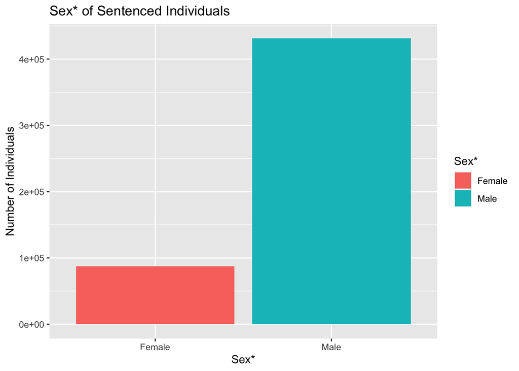

```r
us_sent %>%
  mutate(sex = case_when(sex == 0 ~ "Male",
                         sex == 1 ~ "Female")) %>%
  ggplot() +
  geom_bar(aes(x = sex, fill = sex)) +
  labs(x = "Sex*",
       title = "Sex* of Sentenced Individuals",
       y = "Number of Individuals",
       fill = "Sex*")
```

#### Race

```r
us_sent %>%
  distinct(race)
```

```
## # A tibble: 4 × 1
##   race
##   <chr>
## 1 white
## 2 black
## 3 other
## 4 hispanic
```

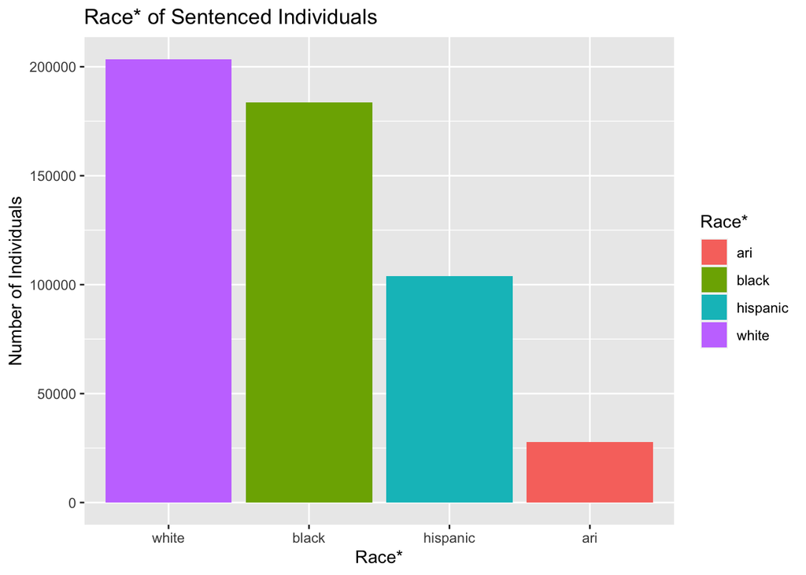

```r
us_sent %>%
  mutate(race = case_when(race == "other" ~ "ari",
                         TRUE ~ race)) %>%
  ggplot() +
  geom_bar(aes(x = fct_infreq(race), fill = race)) +
  labs(x = "Race*",
       title = "Race* of Sentenced Individuals",
       y = "Number of Individuals",
       fill = "Race*")
```

#### Race and Sex

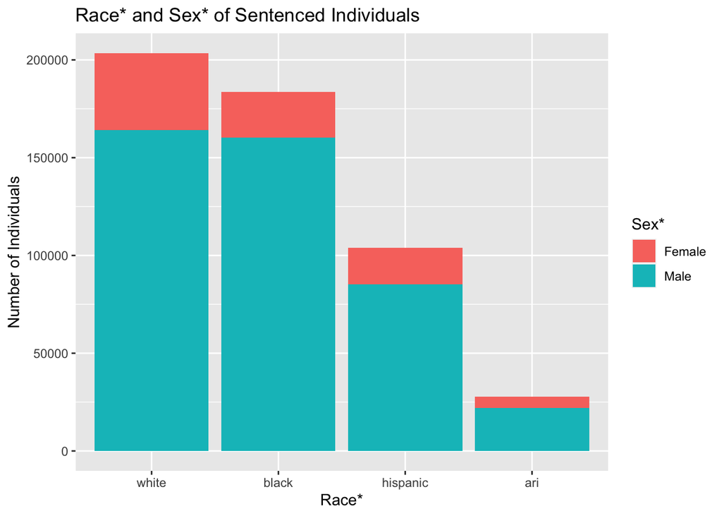

```r
us_sent %>%
  mutate(race = case_when(race == "other" ~ "ari",
                         TRUE ~ race)) %>%
  mutate(sex = case_when(sex == 0 ~ "Male",
                         sex == 1 ~ "Female")) %>%
  ggplot() +
  geom_bar(aes(x = fct_infreq(race), fill = sex)) +
  labs(x = "Race*",
       title = "Race* and Sex* of Sentenced Individuals",
       y = "Number of Individuals",
       fill = "Sex*")
```

**To add**: - what do we divide by? - You may look at this plot and say that whites are sentenced at the federal district court more than black individuals. This is where it is important to look at the population in each area.

#### Bringing in the spatial district files

- https://www.openicpsr.org/openicpsr/project/100069/version/V1/view
- Downloading census data from the API.
- Joining to census data
- Limitations of census data

### Where

Let’s check what districts we have in the data. We can do this using `distinct(district)`.

```r
us_sent %>%
  distinct(district)
```

```
## # A tibble: 93 × 1
##    district
##    <chr>
##  1 Dist of Columbia
##  2 Maine
##  3 Massachusetts
##  4 New Hampshire
##  5 Puerto Rico
##  6 Rhode Island
##  7 Connecticut
##  8 New York East
##  9 New York North
## 10 New York South
## # ℹ 83 more rows
```

You’ll notice that certain states are a single district on their own. Other larger states are split into several districts (e.g. New York East, New York North).

Q: If you live in the United States, can you identify which district you live in?

**To Do** Add a link to a reference where someone could also find which district their town/city is in.

We can use `distinct` to figure out what distinct districts we have in our dataset, but we are also interested in finding out how many sentences were made in each district and we will want to think about this question in relation to the population of those districts, which can be quite nuanced and we will come back to this later.

Our goals in this next section are to think about ways we can explore the question “Where did those sentences occur” in a visual way.

**Learning aims**

- introduce factors as a data type
- explain why it might be better to put our names on the y axis instead of the x-axis for many categories and those with longer names. This makes it more readable.
- explain that automatically categorical data will be placed in alphabetical order.
- we can reconfigure the graph using functions from the `forcats` package.
- This is a good example for when you might want to order it in terms of frequency (i.e. the count) using `fct_infreq`
- We may also want to reverse the order to see the districts which have the most sentences at the top of our plot using `fct_rev`.

#### Number of individuals sentences across districts

##### Base Bar Plot

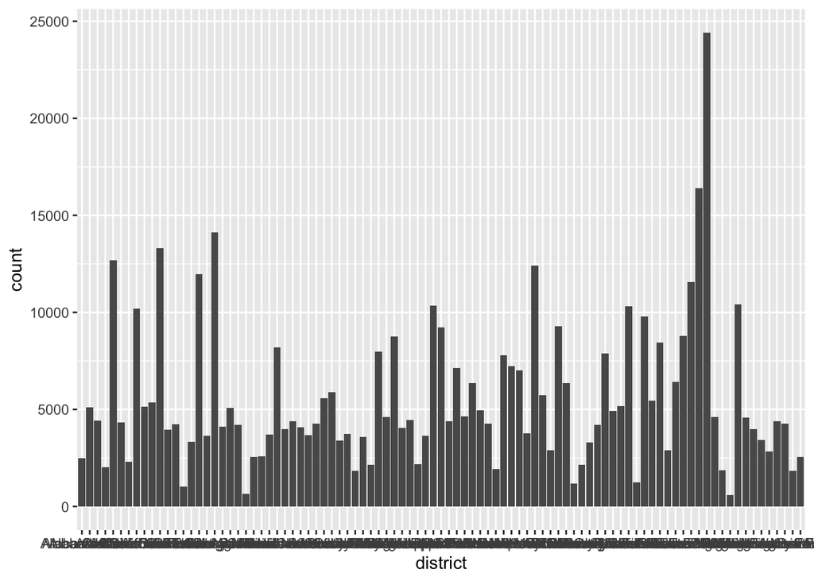

```r
ggplot(us_sent) +
  geom_bar(aes(x = district))
```

##### District on the y-axis

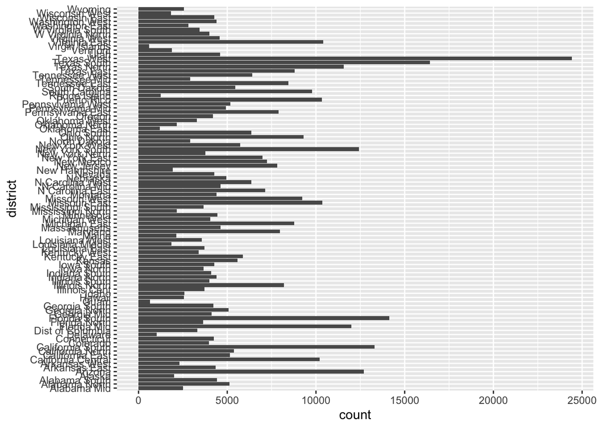

```r
ggplot(us_sent) +
  geom_bar(aes(y = district))
```